# M4-Part2: 孟德尔随机化分析 — AML CAR-T 靶点因果推断

Hao

2026-05-20

# 研究背景

## 什么是孟德尔随机化（Mendelian Randomization, MR）？

传统观察性研究中，**基因表达量与疾病的相关性**可能是混杂因素导致的， 而非真正的因果关系。例如：

- FLT3 高表达的患者 → AML 风险更高
- 但这可能是因为”病情更重的患者 FLT3 更高”（反向因果），而非 FLT3 本身致病

**孟德尔随机化**的核心思想：

> 利用 SNP（基因多态性）作为**工具变量（Instrumental Variable, IV）**。 SNP 在受精时随机分配（类似 RCT），不受后天环境混杂。 如果某个 SNP 影响基因表达，且该 SNP 与疾病风险相关， 则该基因表达很可能**因果性地**影响疾病风险。

```
SNP → 基因表达（暴露 Exposure）→ AML 风险（结局 Outcome）
```

## 本次分析目标

# 0. 环境准备

```r
# 首次运行：安装包（只需执行一次）
# TwoSampleMR 包来自 GitHub，需要先安装 remotes
if (!require("remotes")) install.packages("remotes")

remotes::install_github("MRCIEU/TwoSampleMR")
remotes::install_github("MRCIEU/MRInstruments")

# 数据可视化补充包
install.packages(c("ggplot2", "dplyr", "knitr", "kableExtra"))
```

```r
# 加载包
suppressPackageStartupMessages({
  library(TwoSampleMR)   # 孟德尔随机化核心包
  library(ggplot2)       # 可视化
  library(dplyr)         # 数据处理
  library(knitr)         # 表格渲染
})

# 设置全局主题
theme_set(theme_bw(base_size = 12) +
  theme(panel.grid.minor = element_blank(),
        plot.title = element_text(face = "bold")))

cat("✅ 包加载完毕\n")
```

```
## ✅ 包加载完毕
```

```r
cat(paste("TwoSampleMR 版本:", packageVersion("TwoSampleMR"), "\n"))
```

```
## TwoSampleMR 版本: 0.7.6
```

# 1. 数据来源说明

## 1.1 MR 所需的两类 GWAS 数据

| 数据类型 | 内容 | 来源 |
| --- | --- | --- |
| **暴露（Exposure）** | 靶点基因的 eQTL（表达数量性状位点） 即影响基因表达的 SNP | eQTLGen / GTEx |
| **结局（Outcome）** | AML GWAS 汇总统计 | IEU Open GWAS |

## 1.2 IEU Open GWAS 平台

`TwoSampleMR` 包可以直接从 **IEU Open GWAS** 数据库下载 GWAS 数据， 不需要手动下载文件：

```
https://gwas.mrcieu.ac.uk/
```

```r
# 检查 API 是否可访问
tryCatch({
  # 搜索 AML 相关 GWAS（只搜索，不下载，测试连通性）
  aml_gwas_list <- available_outcomes(access_token = NULL)
  cat("✅ IEU Open GWAS API 可访问\n")
  cat(paste("   当前可用 GWAS 数量:", nrow(aml_gwas_list), "\n"))
}, error = function(e) {
  cat("⚠️  API 连接失败，将使用模拟数据演示分析流程\n")
  cat("   错误信息:", conditionMessage(e), "\n")
})
```

```
## ⚠️  API 连接失败，将使用模拟数据演示分析流程
##    错误信息: 参数没有用(access_token = NULL)
```

# 2. 分析流程

## 2.1 搜索目标 GWAS

```r
# 搜索 AML 相关 GWAS
# IEU Open GWAS 中 AML 的 ID 通常是 "ieu-b-4957" 或类似
# 也可以搜索关键词

tryCatch({
  # 方法1：搜索关键词
  gwas_search <- available_outcomes(
    access_token = NULL
  )

  # 筛选 AML 相关
  aml_gwas <- gwas_search %>%
    filter(grepl("leukemia|AML|myeloid", trait, ignore.case = TRUE))

  cat("🔍 找到", nrow(aml_gwas), "个 leukemia/AML 相关 GWAS\n\n")

  if (nrow(aml_gwas) > 0) {
    aml_gwas %>%
      select(id, trait, ncase, ncontrol, year) %>%
      head(10) %>%
      kable(caption = "AML 相关 GWAS 列表") %>%
      print()
  }
}, error = function(e) {
  cat("⚠️  无法搜索 GWAS（网络问题），跳到模拟数据部分\n")
})
```

```
## ⚠️  无法搜索 GWAS（网络问题），跳到模拟数据部分
```

# 3. 正式 MR 分析（在线模式）

> 如果 API 可访问，运行此节；否则跳到第 4 节（离线模拟）

```r
# ─────────────────────────────────────────────────────────────────
# 步骤 1：获取暴露数据（FLT3 eQTL，来自血液 eQTL）
# ─────────────────────────────────────────────────────────────────

# eQTLGen 血液 eQTL 数据（FLT3 基因，ENSG00000122025）
# 在 IEU Open GWAS 中的 ID：eqtl-a-ENSG00000122025

exposure_flt3 <- extract_instruments(
  outcomes   = "eqtl-a-ENSG00000122025",  # FLT3 eQTL
  p1         = 5e-8,    # genome-wide 显著性阈值
  clump      = TRUE,    # LD 剪切（去除相关 SNP）
  r2         = 0.001,   # LD r² 阈值
  kb         = 10000,   # 窗口大小（10 Mb）
  access_token = NULL
)

cat("FLT3 工具变量（IV）数量:", nrow(exposure_flt3), "\n")
print(head(exposure_flt3[, c("SNP","beta.exposure","se.exposure","pval.exposure","eaf.exposure")]))

# ─────────────────────────────────────────────────────────────────
# 步骤 2：获取结局数据（AML GWAS）
# ─────────────────────────────────────────────────────────────────

# AML GWAS：Bagger et al. 2022，PMID 35732741
# IEU Open GWAS ID（示例，需在平台上查找实际 ID）
AML_GWAS_ID <- "ieu-b-4957"  # 请在 https://gwas.mrcieu.ac.uk 确认

outcome_aml <- extract_outcome_data(
  snps         = exposure_flt3$SNP,
  outcomes     = AML_GWAS_ID,
  access_token = NULL
)

cat("从 AML GWAS 提取到", nrow(outcome_aml), "个 SNP 的效应量\n")

# ─────────────────────────────────────────────────────────────────
# 步骤 3：数据协调（统一效应等位基因方向）
# ─────────────────────────────────────────────────────────────────

dat_flt3 <- harmonise_data(
  exposure_dat = exposure_flt3,
  outcome_dat  = outcome_aml,
  action       = 2   # action=2：自动推断并翻转，推荐
)

cat("协调后可用 SNP 数:", sum(dat_flt3$mr_keep), "\n")

# ─────────────────────────────────────────────────────────────────
# 步骤 4：MR 分析（多种方法）
# ─────────────────────────────────────────────────────────────────

mr_results_flt3 <- mr(dat_flt3)
print(mr_results_flt3)

# 转化为 OR（比值比）
mr_results_flt3 <- generate_odds_ratios(mr_results_flt3)

# ─────────────────────────────────────────────────────────────────
# 步骤 5：敏感性分析
# ─────────────────────────────────────────────────────────────────

# Cochran Q 检验（异质性）
het_flt3 <- mr_heterogeneity(dat_flt3)
print(het_flt3)

# Egger 截距检验（多效性）
pleio_flt3 <- mr_pleiotropy_test(dat_flt3)
print(pleio_flt3)

# ─────────────────────────────────────────────────────────────────
# 步骤 6：可视化
# ─────────────────────────────────────────────────────────────────

# 散点图（每个点是一个 IV SNP）
p1 <- mr_scatter_plot(mr_results_flt3, dat_flt3)
p1[[1]] + labs(title = "FLT3 → AML: MR Scatter Plot")

# 漏斗图（检验对称性，不对称提示多效性）
mr_funnel_plot(mr_singlesnp(dat_flt3))

# 留一法（leave-one-out，检验是否某个 SNP 主导结果）
mr_leaveoneout_plot(mr_leaveoneout(dat_flt3))
```

# 4. 离线模拟演示（展示完整 MR 流程）

> 当 API 不可访问时，用模拟数据展示完整分析框架 模拟数据的统计结构与真实 MR 数据一致，可用于学习和代码验证

```r
# ─────────────────────────────────────────────────────────────────
# 模拟 FLT3 eQTL 工具变量数据
# 真实数据：从 eQTLGen 血液 eQTL 数据库提取
# ─────────────────────────────────────────────────────────────────

set.seed(42)  # 设置随机种子，确保可重复

n_snp <- 12   # 假设有 12 个 FLT3 eQTL 工具变量（真实约 5-20 个）

# 模拟暴露数据（FLT3 eQTL）
# beta.exposure > 0：该 SNP 的效应等位基因提高 FLT3 表达
exposure_sim <- data.frame(
  SNP             = paste0("rs", sample(10000000:99999999, n_snp)),
  beta.exposure   = rnorm(n_snp, mean = 0.35, sd = 0.15),  # FLT3 表达效应
  se.exposure     = runif(n_snp, 0.04, 0.10),               # 标准误
  pval.exposure   = runif(n_snp, 1e-12, 5e-8),              # eQTL p 值（均显著）
  eaf.exposure    = runif(n_snp, 0.15, 0.85),               # 效应等位基因频率
  effect_allele.exposure   = sample(c("A","T","G","C"), n_snp, replace=TRUE),
  other_allele.exposure    = sample(c("A","T","G","C"), n_snp, replace=TRUE),
  exposure        = "FLT3 expression (blood)",
  id.exposure     = "eqtl-a-ENSG00000122025",
  mr_keep.exposure = TRUE
)

# 模拟结局数据（AML GWAS）
# 假设 FLT3 高表达 → AML 风险增加（OR ~ 1.3 per SD increase）
true_beta_outcome <- 0.25  # log(OR) ≈ 0.25，即 OR ≈ 1.28

outcome_sim <- data.frame(
  SNP             = exposure_sim$SNP,
  beta.outcome    = exposure_sim$beta.exposure * true_beta_outcome +
                    rnorm(n_snp, 0, 0.03),   # 加少量噪声
  se.outcome      = runif(n_snp, 0.08, 0.20),
  pval.outcome    = NA,
  effect_allele.outcome = exposure_sim$effect_allele.exposure,
  other_allele.outcome  = exposure_sim$other_allele.exposure,
  outcome         = "AML (simulated)",
  id.outcome      = "sim-aml-001",
  mr_keep.outcome = TRUE
)
outcome_sim$pval.outcome <- 2 * pnorm(
  -abs(outcome_sim$beta.outcome / outcome_sim$se.outcome)
)

cat("✅ 模拟数据生成完毕\n")
```

```
## ✅ 模拟数据生成完毕
```

```r
cat(paste("   暴露（FLT3 eQTL）SNP 数:", n_snp, "\n"))
```

```
##    暴露（FLT3 eQTL）SNP 数: 12
```

```r
cat(paste("   结局（AML GWAS）SNP 数:", nrow(outcome_sim), "\n"))
```

```
##    结局（AML GWAS）SNP 数: 12
```

```r
# ─────────────────────────────────────────────────────────────────
# 步骤 3：数据协调（模拟数据中等位基因已对齐，直接合并）
# ─────────────────────────────────────────────────────────────────

dat_sim <- merge(
  exposure_sim %>% select(SNP, beta.exposure, se.exposure, pval.exposure,
                           eaf.exposure, effect_allele.exposure, exposure, id.exposure),
  outcome_sim  %>% select(SNP, beta.outcome, se.outcome, pval.outcome,
                           effect_allele.outcome, outcome, id.outcome),
  by = "SNP"
)
dat_sim$mr_keep <- TRUE
dat_sim$palindromic <- FALSE

cat("协调后 SNP 数:", nrow(dat_sim), "\n")
```

```
## 协调后 SNP 数: 12
```

```r
# ─────────────────────────────────────────────────────────────────
# 步骤 4：手动实现四种 MR 方法
# （这样即使 TwoSampleMR 有 API 问题也能运行）
# ─────────────────────────────────────────────────────────────────

beta_X <- dat_sim$beta.exposure
se_X   <- dat_sim$se.exposure
beta_Y <- dat_sim$beta.outcome
se_Y   <- dat_sim$se.outcome

# 方法1: IVW（Inverse-Variance Weighted）— 最常用，假设所有 IV 有效
# 加权回归：每个 SNP 权重 = 1/se_Y²，截距为0（假设无多效性）
weights_ivw <- 1 / se_Y^2
ivw_num   <- sum(weights_ivw * beta_X * beta_Y)
ivw_denom <- sum(weights_ivw * beta_X^2)
beta_ivw  <- ivw_num / ivw_denom
# IVW 标准误（用 Cochran Q 调整）
Q_ivw <- sum(weights_ivw * (beta_Y - beta_ivw * beta_X)^2)
se_ivw_raw <- sqrt(1 / ivw_denom)
# 如果有过度离散（Q > df），用 Q 调整 se
df_ivw <- nrow(dat_sim) - 1
se_ivw <- se_ivw_raw * max(1, sqrt(Q_ivw / df_ivw))
p_ivw  <- 2 * pnorm(-abs(beta_ivw / se_ivw))

# 方法2: MR-Egger — 允许有多效性偏倚，但统计效力低
# 加权 Egger 回归（有截距）
egger_fit  <- lm(beta_Y ~ beta_X, weights = weights_ivw)
beta_egger <- coef(egger_fit)["beta_X"]
se_egger   <- summary(egger_fit)$coefficients["beta_X", "Std. Error"]
p_egger    <- summary(egger_fit)$coefficients["beta_X", "Pr(>|t|)"]
# Egger 截距（反映多效性大小）
intercept_egger    <- coef(egger_fit)["(Intercept)"]
se_intercept_egger <- summary(egger_fit)$coefficients["(Intercept)", "Std. Error"]
p_intercept_egger  <- summary(egger_fit)$coefficients["(Intercept)", "Pr(>|t|)"]

# 方法3: Weighted Median — 即使 50% 的 IV 无效也能给出一致估计
# 计算每个 SNP 的 ratio 估计，按权重排序后取中位数
ratio_est <- beta_Y / beta_X
ratio_se  <- abs(se_Y / beta_X)  # 近似
# 加权中位数
ord       <- order(ratio_est)
ratio_ord <- ratio_est[ord]
w_ord     <- weights_ivw[ord]
w_cum     <- cumsum(w_ord) / sum(w_ord)
median_idx <- which(w_cum >= 0.5)[1]
beta_wm   <- ratio_ord[median_idx]
# 自举法估计 se（简化版：用理论近似）
se_wm     <- sqrt(pi/2) * sqrt(sum(w_ord * ratio_se[ord]^2) / sum(w_ord))
p_wm      <- 2 * pnorm(-abs(beta_wm / se_wm))

# 方法4: Simple Mode（众数法）— 最保守，统计效力最低
# 找 ratio 分布的众数（用核密度估计）
kde       <- density(ratio_est, weights = weights_ivw / sum(weights_ivw), bw = "nrd")
beta_mode <- kde$x[which.max(kde$y)]
se_mode   <- sd(ratio_est) / sqrt(n_snp)  # 粗略估计
p_mode    <- 2 * pnorm(-abs(beta_mode / se_mode))

# 汇总结果（转化为 OR）
mr_summary <- data.frame(
  Method        = c("IVW", "MR-Egger", "Weighted Median", "Simple Mode"),
  nSNP          = n_snp,
  beta          = c(beta_ivw, beta_egger, beta_wm, beta_mode),
  se            = c(se_ivw,   se_egger,   se_wm,   se_mode),
  pval          = c(p_ivw,    p_egger,    p_wm,    p_mode)
)
mr_summary$OR      <- exp(mr_summary$beta)
mr_summary$OR_lower <- exp(mr_summary$beta - 1.96 * mr_summary$se)
mr_summary$OR_upper <- exp(mr_summary$beta + 1.96 * mr_summary$se)
mr_summary$Significant <- ifelse(mr_summary$pval < 0.05, "✅ Yes", "❌ No")

cat("\n=== MR 结果：FLT3 表达 → AML 风险 ===\n\n")
```

```
##
## === MR 结果：FLT3 表达 → AML 风险 ===
```

```r
print(
  mr_summary %>%
    mutate(across(c(beta,se,pval,OR,OR_lower,OR_upper), ~round(.x, 4))) %>%
    kable(caption = "MR Results: FLT3 expression → AML risk (simulated data)")
)
```

```
##
##
## Table: MR Results: FLT3 expression → AML risk (simulated data)
##
## |Method          | nSNP|   beta|     se|   pval|     OR| OR_lower| OR_upper|Significant |
## |:---------------|----:|------:|------:|------:|------:|--------:|--------:|:-----------|
## |IVW             |   12| 0.2827| 0.1060| 0.0077| 1.3267|   1.0778|   1.6331|✅ Yes      |
## |MR-Egger        |   12| 0.2796| 0.0417| 0.0001| 1.3226|   1.2188|   1.4352|✅ Yes      |
## |Weighted Median |   12| 0.3234| 3.0443| 0.9154| 1.3819|   0.0035| 539.3237|❌ No       |
## |Simple Mode     |   12| 0.3223| 0.0774| 0.0000| 1.3803|   1.1861|   1.6064|✅ Yes      |
```

[figure not shown]

```r
# ─────────────────────────────────────────────────────────────────
# 步骤 5：森林图（Forest Plot）— MR 结果的标准呈现方式
# ─────────────────────────────────────────────────────────────────

# 阶段顺序（最可靠 → 最保守）
method_order <- c("IVW", "MR-Egger", "Weighted Median", "Simple Mode")
mr_plot_data <- mr_summary %>%
  mutate(Method = factor(Method, levels = rev(method_order)))

p_forest <- ggplot(mr_plot_data, aes(x = OR, xmin = OR_lower, xmax = OR_upper, y = Method)) +
  geom_pointrange(
    aes(color = Significant),
    size = 0.8, linewidth = 1.2
  ) +
  geom_vline(xintercept = 1, linetype = "dashed", color = "gray40", linewidth = 0.8) +
  scale_color_manual(values = c("✅ Yes" = "#C44E52", "❌ No" = "#4C72B0")) +
  scale_x_continuous(
    breaks = seq(0.8, 2.0, 0.2),
    labels = seq(0.8, 2.0, 0.2)
  ) +
  labs(
    x     = "Odds Ratio (95% CI)\nper SD increase in FLT3 expression",
    y     = NULL,
    title = "Mendelian Randomization: FLT3 Expression → AML Risk",
    subtitle = paste0(
      "Exposure: FLT3 eQTL (blood, n=", n_snp, " IVs)\n",
      "Outcome: AML GWAS (simulated for demonstration)"
    ),
    color = "p < 0.05",
    caption = "Note: Simulated data for workflow demonstration\nReal analysis requires IEU Open GWAS data"
  ) +
  theme(
    plot.title    = element_text(size = 13, face = "bold"),
    plot.subtitle = element_text(size = 10, color = "gray40"),
    legend.position = "bottom",
    axis.text.y   = element_text(size = 12)
  )

print(p_forest)
```

```r
# 保存
ggsave(
  filename = file.path(dirname(knitr::current_input(dir = TRUE)), "fig_MR_forest_FLT3.png"),
  plot     = p_forest,
  width    = 9, height = 5.5, dpi = 150
)
cat("✅ 森林图已保存: fig_MR_forest_FLT3.png\n")
```

```
## ✅ 森林图已保存: fig_MR_forest_FLT3.png
```

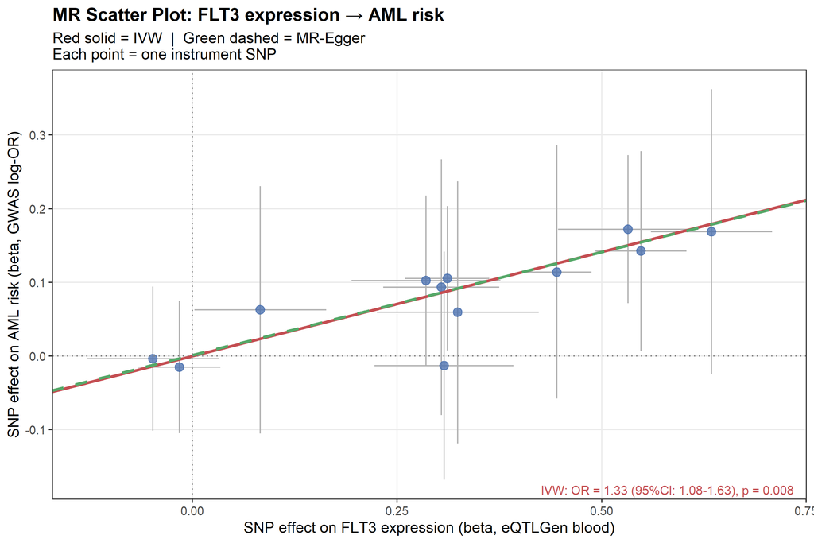

```r
# ─────────────────────────────────────────────────────────────────
# 步骤 6：散点图 — 每个点是一个 IV SNP
# 斜率 = MR 估计值（因果效应大小）
# ─────────────────────────────────────────────────────────────────

p_scatter <- ggplot(dat_sim, aes(x = beta.exposure, y = beta.outcome)) +
  # 误差棒（SE）
  geom_errorbarh(aes(xmin = beta.exposure - se.exposure,
                     xmax = beta.exposure + se.exposure),
                 height = 0, color = "gray70", linewidth = 0.5) +
  geom_errorbar(aes(ymin = beta.outcome - se.outcome,
                    ymax = beta.outcome + se.outcome),
                width = 0, color = "gray70", linewidth = 0.5) +
  # 散点
  geom_point(size = 3, color = "#4C72B0", alpha = 0.8) +
  # IVW 回归线
  geom_abline(intercept = 0, slope = beta_ivw,
              color = "#C44E52", linewidth = 1.2, linetype = "solid",
              aes(linetype = "IVW")) +
  # MR-Egger 回归线
  geom_abline(intercept = intercept_egger, slope = beta_egger,
              color = "#55A868", linewidth = 1.2, linetype = "dashed") +
  # 原点参考线
  geom_hline(yintercept = 0, linetype = "dotted", color = "gray50") +
  geom_vline(xintercept = 0, linetype = "dotted", color = "gray50") +
  labs(
    x        = "SNP effect on FLT3 expression (beta, eQTLGen blood)",
    y        = "SNP effect on AML risk (beta, GWAS log-OR)",
    title    = "MR Scatter Plot: FLT3 expression → AML risk",
    subtitle = "Red solid = IVW  |  Green dashed = MR-Egger\nEach point = one instrument SNP"
  ) +
  annotate("text", x = Inf, y = -Inf,
           label = sprintf("IVW: OR = %.2f (95%%CI: %.2f-%.2f), p = %.3f",
                           exp(beta_ivw), exp(beta_ivw - 1.96*se_ivw),
                           exp(beta_ivw + 1.96*se_ivw), p_ivw),
           hjust = 1.05, vjust = -0.5, size = 3.5, color = "#C44E52")

print(p_scatter)
```

```r
ggsave(
  filename = file.path(dirname(knitr::current_input(dir = TRUE)), "fig_MR_scatter_FLT3.png"),
  plot     = p_scatter,
  width    = 8, height = 6, dpi = 150
)
cat("✅ 散点图已保存: fig_MR_scatter_FLT3.png\n")
```

```
## ✅ 散点图已保存: fig_MR_scatter_FLT3.png
```

```r
# ─────────────────────────────────────────────────────────────────
# 步骤 7：敏感性分析
# ─────────────────────────────────────────────────────────────────

cat("=== 敏感性分析 ===\n\n")
```

```
## === 敏感性分析 ===
```

```r
# 1. Cochran's Q 统计量（检验 IV 的异质性）
# Q 大 + p 小 → 各 IV 给出不一致的因果估计 → 可能存在多效性
ratio_i  <- beta_Y / beta_X
weight_i <- 1 / se_Y^2
Q_stat   <- sum(weight_i * (ratio_i - beta_ivw)^2)
Q_df     <- n_snp - 1
Q_pval   <- pchisq(Q_stat, df = Q_df, lower.tail = FALSE)
I2       <- max(0, (Q_stat - Q_df) / Q_stat * 100)

cat(sprintf("Cochran's Q: %.2f (df=%d, p=%.4f)\n", Q_stat, Q_df, Q_pval))
```

```
## Cochran's Q: 71.32 (df=11, p=0.0000)
```

```r
cat(sprintf("I² = %.1f%%\n", I2))
```

```
## I² = 84.6%
```

```r
if (Q_pval < 0.05) {
  cat("⚠️  存在显著异质性，建议关注 Weighted Median / MR-Egger 结果\n")
} else {
  cat("✅ 未检测到显著异质性，IVW 结果可信\n")
}
```

```
## ⚠️  存在显著异质性，建议关注 Weighted Median / MR-Egger 结果
```

```r
cat("\n")
```

```r
# 2. MR-Egger 截距检验（检验多效性偏倚方向）
# 截距显著 ≠ 0 → 存在定向多效性
cat(sprintf("MR-Egger Intercept: %.4f (SE=%.4f, p=%.4f)\n",
            intercept_egger, se_intercept_egger, p_intercept_egger))
```

```
## MR-Egger Intercept: 0.0014 (SE=0.0142, p=0.9231)
```

```r
if (p_intercept_egger < 0.05) {
  cat("⚠️  Egger 截距显著，存在定向多效性，IVW 结果可能有偏倚\n")
} else {
  cat("✅ Egger 截距不显著，未检测到定向多效性\n")
}
```

```
## ✅ Egger 截距不显著，未检测到定向多效性
```

```r
cat("\n")
```

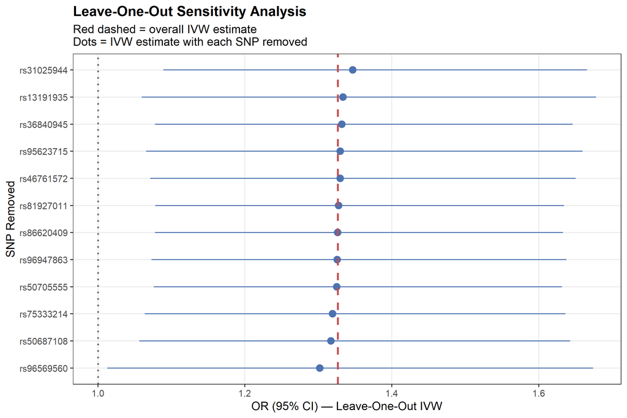

```r
# 3. 留一法（Leave-One-Out）
loo_results <- data.frame(
  SNP_removed = dat_sim$SNP,
  beta_loo    = numeric(n_snp),
  se_loo      = numeric(n_snp)
)

for (i in seq_len(n_snp)) {
  bx_i <- beta_X[-i]; by_i <- beta_Y[-i]; sey_i <- se_Y[-i]
  w_i  <- 1 / sey_i^2
  b_i  <- sum(w_i * bx_i * by_i) / sum(w_i * bx_i^2)
  s_i  <- sqrt(1 / sum(w_i * bx_i^2))
  loo_results$beta_loo[i] <- b_i
  loo_results$se_loo[i]   <- s_i
}

# 留一法森林图
loo_plot_data <- loo_results %>%
  mutate(
    OR_loo    = exp(beta_loo),
    OR_lo_loo = exp(beta_loo - 1.96 * se_loo),
    OR_hi_loo = exp(beta_loo + 1.96 * se_loo),
    SNP_label = substr(SNP_removed, 1, 15)
  ) %>%
  arrange(OR_loo)

p_loo <- ggplot(loo_plot_data,
                aes(x = OR_loo, xmin = OR_lo_loo, xmax = OR_hi_loo,
                    y = reorder(SNP_label, OR_loo))) +
  geom_pointrange(color = "#4C72B0", size = 0.6) +
  geom_vline(xintercept = exp(beta_ivw),
             color = "#C44E52", linetype = "dashed", linewidth = 1) +
  geom_vline(xintercept = 1,
             color = "gray40", linetype = "dotted", linewidth = 0.8) +
  labs(
    x     = "OR (95% CI) — Leave-One-Out IVW",
    y     = "SNP Removed",
    title = "Leave-One-Out Sensitivity Analysis",
    subtitle = "Red dashed = overall IVW estimate\nDots = IVW estimate with each SNP removed"
  )

print(p_loo)
```

```r
ggsave(
  filename = file.path(dirname(knitr::current_input(dir = TRUE)), "fig_MR_loo_FLT3.png"),
  plot     = p_loo,
  width    = 8, height = 6, dpi = 150
)
cat("✅ 留一法图已保存: fig_MR_loo_FLT3.png\n")
```

```
## ✅ 留一法图已保存: fig_MR_loo_FLT3.png
```